# Homework 4 - Working with large datasets

Qinghua Li

02/14/2025

# Question 1 - benchmark data.table’s grouping on real data

Download the merged College Scorecard data from (2009-2016) from here: https://www.dropbox.com/s/ex0u45rlrjr6h7e/Scorecard_2009-2016.csv?dl=0

This file is the final merged form of the original data that was discussed in class, using the shell operation. Please use this file for the subsequent questions. Excluding the header, there should be 67,418 rows in this file.

In class we performed some simple subsetting and grouping operations. The lecture notes use a previous version of the dataset, and since they were compiled, `CONTROL` is now integer valued, and the `TUITFTE` and `SAT_AVG` columns will need to be coerced to a numeric using `as.numeric`, before you can work with it. (This will give a warning about NAs introduced, which you should ignore.)

Also you should convert `CONTROL` to a factor, and then change the levels 1,2,3 to instead `pub`,`pnp`,`pfp`.

From the data dictionary, we have:

| C | Value |
| --- | --- |
| 1 | Public |
| 2 | Private nonprofit |
| 3 | Private for-profit |

First, tabulate the number of schools you have in the table for each value of `CONTROL` (you can use data.table or base R for this). Also tabulate, the number of schools for each value of `CONTROL` that have non-NA values for both `TUITFTE` *and* `SAT_AVG`.

Then, compute the mean and SD tuition per FTE and the mean and SD average SAT for each of the classes of ownership (pub, pnp, pfp), (1) using data.table, and (2) using `aggregate` with the columns `TUITFTE`, `SAT_AVG`, `CONTROL` and your NA-removed mean and sd function. Confirm by eye that they give the same result and compare speed. You can benchmark with `times=10`.

A typical use of aggregate is:

```
aggregate(df[,c("col1","col2")], df[,"grouping"], function(x) ...)
```

```r
library(data.table)
library(microbenchmark)

file <- "Data/Scorecard_2009-2016.csv"
df <- fread(file)
df$SAT_AVG <- as.numeric(df$SAT_AVG)
df$TUITFTE <- as.numeric(df$TUITFTE)
df$CONTROL <- as.factor(df$CONTROL)
levels(df$CONTROL) <- c("pub", "pnp", "pfp")
```

- tabulate the number of schools for each value of `CONTROL`

```r
df[, length(INSTNM), by = CONTROL]
```

```
##    CONTROL    V1
##     <fctr> <int>
## 1:     pub 18638
## 2:     pnp 17718
## 3:     pfp 31062
```

- tabulate the number of schools for each value of `CONTROL` that have non-NA values for both `TUITFTE` *and* `SAT_AVG`

```r
df[(!is.na(TUITFTE)) & (!is.na(SAT_AVG)), .N, by=CONTROL]
```

```
##    CONTROL     N
##     <fctr> <int>
## 1:     pub  4673
## 2:     pnp  7523
## 3:     pfp    89
```

**Using data.table**

```r
avg <- function(x) mean(x, na.rm = TRUE)
get_sd <- function(x) sd(x, na.rm =  TRUE)
```

- Mean and SD for `TUITFTE`

```r
df[, .(mean = avg(TUITFTE),sd = get_sd(TUITFTE)), by = CONTROL ]
```

```
##    CONTROL      mean        sd
##     <fctr>     <num>     <num>
## 1:     pub  4228.865  5056.246
## 2:     pnp 14265.358 24634.090
## 3:     pfp 10661.401 10945.809
```

- Mean and SD for `SAT_AVG`

```r
df[, .(mean = avg(SAT_AVG),sd = get_sd(SAT_AVG)), by = CONTROL ]
```

```
##    CONTROL     mean       sd
##     <fctr>    <num>    <num>
## 1:     pub 1042.886 113.0328
## 2:     pnp 1079.230 143.4723
## 3:     pfp 1004.360 112.9672
```

**Using aggregate**

- Mean for `TUITFTE` and `SAT_AVG`

```r
aggregate(df[,c("TUITFTE","SAT_AVG")], df[,"CONTROL"], avg)
```

```
##   CONTROL   TUITFTE  SAT_AVG
## 1     pub  4228.865 1042.886
## 2     pnp 14265.358 1079.230
## 3     pfp 10661.401 1004.360
```

- SD for `TUITFTE` and `SAT_AVG`

```r
aggregate(df[,c("TUITFTE","SAT_AVG")], df[,"CONTROL"], get_sd)
```

```
##   CONTROL   TUITFTE  SAT_AVG
## 1     pub  5056.246 113.0328
## 2     pnp 24634.090 143.4723
## 3     pfp 10945.809 112.9672
```

**Compare**

```r
microbenchmark(df[, .(mean.tuitfte = avg(TUITFTE), sd.tuitfte = get_sd(TUITFTE),
                      mean.satavg = avg(SAT_AVG), sd.satavg = get_sd(SAT_AVG)),
                  by = CONTROL],

               aggregate(df[,c("TUITFTE","SAT_AVG")], df[,"CONTROL"],
                         function(x) c(mean = avg(x), sd = get_sd(x))),
               times = 10)
```

```
## Unit: milliseconds
##                                                                                                                                                 expr
##  df[, .(mean.tuitfte = avg(TUITFTE), sd.tuitfte = get_sd(TUITFTE),      mean.satavg = avg(SAT_AVG), sd.satavg = get_sd(SAT_AVG)),      by = CONTROL]
##                                         aggregate(df[, c("TUITFTE", "SAT_AVG")], df[, "CONTROL"], function(x) c(mean = avg(x),      sd = get_sd(x)))
##      min      lq     mean   median      uq     max neval
##   6.9417  7.4437  8.74576  8.77115  9.9114 11.3258    10
##  29.8681 31.5055 35.51428 35.58965 38.1952 41.9593    10
```

# Question 2- doing more with “by” in data.table

Make a subset of the data, called `scores.sub`, which has complete data for both `TUITFTE` and `SAT_AVG`. You can look up the `na.omit` function in data.table.

Make a plot of `SAT_AVG` over `TUITFTE`, and color the points by `CONTROL`, with x-limits of [0-40,000] and y-limits of [500-1600].

Now tabulate the number of schools that have tuition per FTE over 20,000 and/or average SAT over 1200, grouped by ownership category. Your output should be sorted on the groupings you define, so the first row should be public, TUITFTE < 20,000 and SAT_AVG < 1200, and so on for 12 rows. See the Introduction vignette for data.table for insight on how to perform this operation. Hint: “sorted by” and “expressions in by”.

**Scatter plot of `SAT_AVG` over `TUITFTE`**

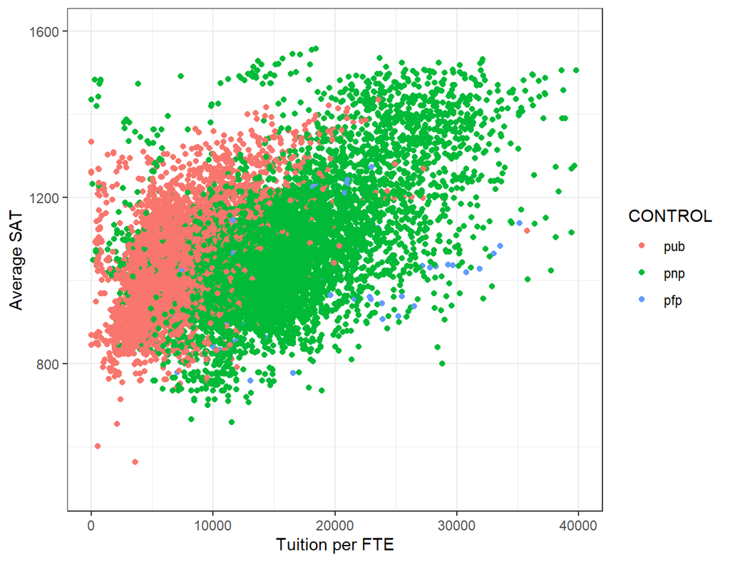

```r
scores.sub <- na.omit(df, cols = c("TUITFTE", "SAT_AVG"))

library(ggplot2)
ggplot(scores.sub, aes(x = TUITFTE, y = SAT_AVG, color = CONTROL)) +
  geom_point() +
  labs(x = "Tuition per FTE", y = "Average SAT") +
  xlim(0, 40000) +
  ylim(500, 1600) +
  theme_bw()
```

**tabulate the number of schools that have tuition per FTE over 20,000 and/or average SAT over 1200, grouped by ownership**

```r
scores.sub[, .N, keyby = .(CONTROL, (TUITFTE > 20000), (SAT_AVG > 1200))]
```

```
## Key: <CONTROL, TUITFTE, SAT_AVG>
##     CONTROL TUITFTE SAT_AVG     N
##      <fctr>  <lgcl>  <lgcl> <int>
##  1:     pub   FALSE   FALSE  4207
##  2:     pub   FALSE    TRUE   437
##  3:     pub    TRUE   FALSE    12
##  4:     pub    TRUE    TRUE    17
##  5:     pnp   FALSE   FALSE  5648
##  6:     pnp   FALSE    TRUE   411
##  7:     pnp    TRUE   FALSE   611
##  8:     pnp    TRUE    TRUE   853
##  9:     pfp   FALSE   FALSE    61
## 10:     pfp   FALSE    TRUE     2
## 11:     pfp    TRUE   FALSE    22
## 12:     pfp    TRUE    TRUE     4
```

# Question 3 - subsets of data

Use data.table to obtain the tuition per FTE and average SAT for the two schools with the top average SAT within each ownership group. Hint: I performed this in two steps, first by ordering `scores.sub`, and then using “subset of data”. Make sure to avoid returning all of the columns…

```r
setkey(scores.sub, SAT_AVG)
rbind(scores.sub[CONTROL == "pub",.(CONTROL, INSTNM, SAT_AVG, TUITFTE)][order(-SAT_AVG)][1:2],
      scores.sub[CONTROL == "pnp",.(CONTROL, INSTNM, SAT_AVG, TUITFTE)][order(-SAT_AVG)][1:2],
      scores.sub[CONTROL == "pfp",.(CONTROL, INSTNM, SAT_AVG, TUITFTE)][order(-SAT_AVG)][1:2])
```

```
##    CONTROL                             INSTNM SAT_AVG TUITFTE
##     <fctr>                             <char>   <num>   <num>
## 1:     pub   University of Michigan-Ann Arbor    1436   23581
## 2:     pub  University of California-Berkeley    1422   19498
## 3:     pnp California Institute of Technology    1558   18456
## 4:     pnp California Institute of Technology    1555   18091
## 5:     pfp    DigiPen Institute of Technology    1274   22998
## 6:     pfp    DigiPen Institute of Technology    1242   21020
```

# Question 4 - MovieLens sparse dataset

As we mentioned in class, one common form of sparse data is when we have information about individuals and their interaction with a large set of items (e.g. movies, products, etc.). The interactions may be ratings or purchases. One publicly available dataset of movie ratings is *MovieLens*, which has a 1 MB download available here:

https://grouplens.org/datasets/movielens/

Download the `ml-latest-small.zip` dataset. Take a look at each of the CSV files. How many of the movies have the “Comedy” genre attached to them?

Build a sparse matrix of the movies by users, and just put a 1 for if the user rated the movie (don’t actually record the value of the rating itself). You can do this by specifying `x=1`. In the abstract, this is a very large matrix, but this is because the user IDs go up to nearly 200,000. Remove the rows of the sparse matrix where there are no ratings to produce a sparse matrix that is roughly ~10,000 by ~600. Use `summary` to investigate the range, quartiles, etc. of number of movies rated by each user.

There are multiple ways to compute the SVD of a sparse matrix. If after manipulating the matrix in its sparse form, it is not too large (as in this case), one can just run `svd` which will coerce the matrix into a dense one. Or there are special functions in packages which are designed to compute (potentially sparse) SVD solutions on sparse matrices. Two such functions are `sparsesvd::sparsesvd` and `irlba::ssvd`. You can choose any of these three methods, in either case you should specify to return only 3 left singular vectors (`nu=3`, `rank=3`, or `k=3`, respectively). For `ssvd` in the irlba package, you should specify that the number of nonzero components in the right singular vectors should be all (the number of rows of x), which will give a warning that you should ignore. All of these methods will produce roughly the same decomposition, with arbitrary sign changes on the singular vectors. The sparse versions are about 1000 times faster, as they do not coerce the matrix into a dense version.

Compute the SVD of the matrix using one of the methods above. Plot the columns of the U matrix against each other: 1 vs 2, 2 vs 3, 1 vs 3. Note that column 1 and 3 are correlated, with a long tail of movies. Investigate the names of these movies. What property can you infer about the top 6 movies in the tail w.r.t. column 1 and 3? Now look at the extremes of column 2 of U. What difference can you tell about the movies, between the smallest values and the largest values in column 2?

Hint: there are a few movies which are in the `movies.csv` file, but are not in the `ratings.csv` file. I recommend to subset the list of movies first, which will help with this problem.

**Comedy Genre**

```r
file <- "Data/ml-latest-small/movies.csv"
movies <- fread(file)

isComdedy <- grepl("Comedy", movies$genres)
table(isComdedy)
```

```
## isComdedy
## FALSE  TRUE
##  5986  3756
```

**Rating**

```r
file <- "Data/ml-latest-small/ratings.csv"
ratings <- fread(file)

library(Matrix)
ratings[order(ratings$movieId),]
```

```
##         userId movieId rating  timestamp
##          <int>   <int>  <num>      <int>
##      1:      1       1    4.0  964982703
##      2:      5       1    4.0  847434962
##      3:      7       1    4.5 1106635946
##      4:     15       1    2.5 1510577970
##      5:     17       1    4.5 1305696483
##     ---
## 100832:    184  193581    4.0 1537109082
## 100833:    184  193583    3.5 1537109545
## 100834:    184  193585    3.5 1537109805
## 100835:    184  193587    3.5 1537110021
## 100836:    331  193609    4.0 1537157606
```

```r
sparseratings<- sparseMatrix(i = (ratings$movieId), j = (ratings$userId), x = 1)
sparseratings.reduced <- sparseratings[rowSums(sparseratings)!= 0,]
dim(sparseratings.reduced)
```

```
## [1] 9724  610
```

```r
summary(colSums(sparseratings.reduced))
```

```
##    Min. 1st Qu.  Median    Mean 3rd Qu.    Max.
##    20.0    35.0    70.5   165.3   168.0  2698.0
```

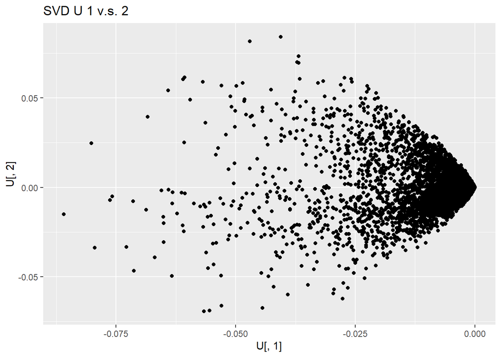

```r
movies.sub <- movies[movies$movieId %in% ratings$movieId,]

## SVD
svd.basic <- svd(sparseratings.reduced, nu = 3)
U <- as.data.frame(svd.basic$u)

## scatter plot
ggplot(U, aes(U[, 1], U[, 2])) +
  geom_point() +
  ggtitle("SVD U 1 v.s. 2")
```

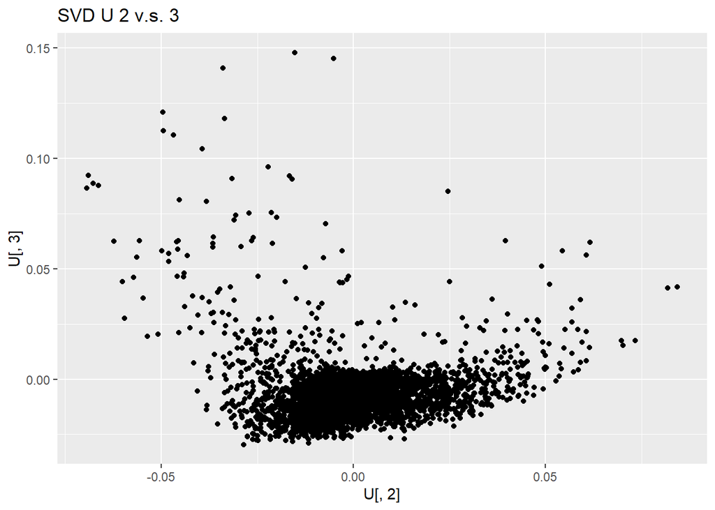

```r
ggplot(U, aes(U[, 2], U[, 3])) +
  geom_point() +
  ggtitle("SVD U 2 v.s. 3")
```

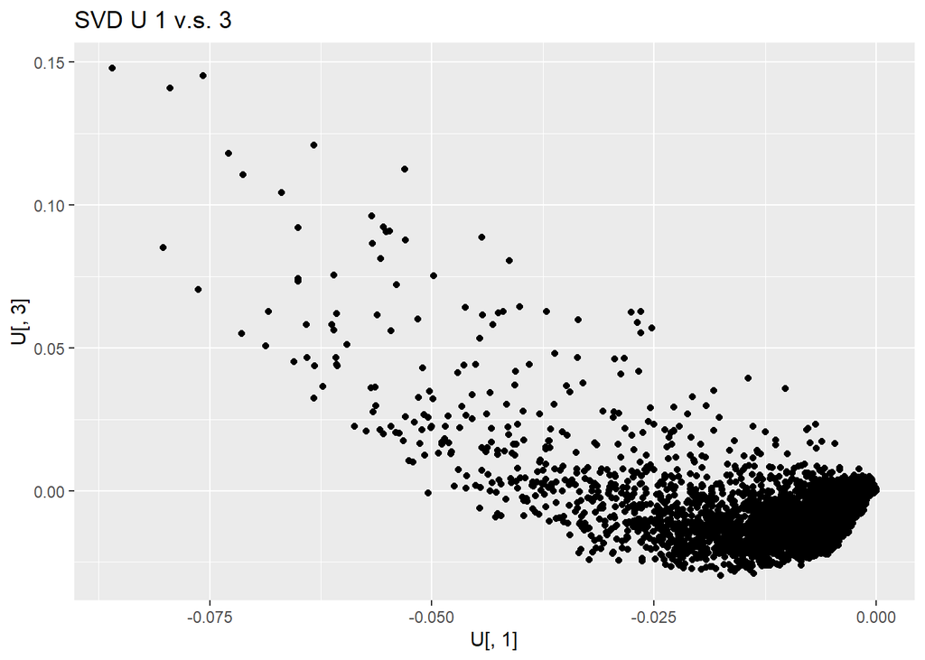

```r
ggplot(U, aes(U[, 1], U[, 3])) +
  geom_point() +
  ggtitle("SVD U 1 v.s. 3")
```

```r
movies.sub[order(U[,1])[1:6],]
```

```
##    movieId                                     title
##      <int>                                    <char>
## 1:     356                       Forrest Gump (1994)
## 2:    2571                        Matrix, The (1999)
## 3:     296                       Pulp Fiction (1994)
## 4:     260 Star Wars: Episode IV - A New Hope (1977)
## 5:     318          Shawshank Redemption, The (1994)
## 6:     593          Silence of the Lambs, The (1991)
##                         genres
##                         <char>
## 1:    Comedy|Drama|Romance|War
## 2:      Action|Sci-Fi|Thriller
## 3: Comedy|Crime|Drama|Thriller
## 4:     Action|Adventure|Sci-Fi
## 5:                 Crime|Drama
## 6:       Crime|Horror|Thriller
```

```r
movies.sub[order(-U[,3])[1:6],]
```

```
##    movieId                            title                      genres
##      <int>                           <char>                      <char>
## 1:     356              Forrest Gump (1994)    Comedy|Drama|Romance|War
## 2:     318 Shawshank Redemption, The (1994)                 Crime|Drama
## 3:     296              Pulp Fiction (1994) Comedy|Crime|Drama|Thriller
## 4:     110                Braveheart (1995)            Action|Drama|War
## 5:     593 Silence of the Lambs, The (1991)       Crime|Horror|Thriller
## 6:     150                 Apollo 13 (1995)        Adventure|Drama|IMAX
```

- The top 6 movies in the tail with respect to column 1 and 3 have a lot overlap, and many of them belong to fictions.

```r
movies.sub[order(U[,2])[1:6],]
```

```
##    movieId                           title
##      <int>                          <char>
## 1:     592                   Batman (1989)
## 2:     457            Fugitive, The (1993)
## 3:     590       Dances with Wolves (1990)
## 4:     380                True Lies (1994)
## 5:     349 Clear and Present Danger (1994)
## 6:     587                    Ghost (1990)
##                                      genres
##                                      <char>
## 1:                    Action|Crime|Thriller
## 2:                                 Thriller
## 3:                  Adventure|Drama|Western
## 4: Action|Adventure|Comedy|Romance|Thriller
## 5:              Action|Crime|Drama|Thriller
## 6:    Comedy|Drama|Fantasy|Romance|Thriller
```

- The movies with the smallest U in column 2 mostly belong to the thriller genres.

```r
movies.sub[order(-U[,2])[1:6],]
```

```
##    movieId                                                 title
##      <int>                                                <char>
## 1:   79132                                      Inception (2010)
## 2:   58559                               Dark Knight, The (2008)
## 3:   68954                                             Up (2009)
## 4:   72998                                         Avatar (2009)
## 5:   59315                                       Iron Man (2008)
## 6:    7153 Lord of the Rings: The Return of the King, The (2003)
##                                             genres
##                                             <char>
## 1: Action|Crime|Drama|Mystery|Sci-Fi|Thriller|IMAX
## 2:                         Action|Crime|Drama|IMAX
## 3:              Adventure|Animation|Children|Drama
## 4:                    Action|Adventure|Sci-Fi|IMAX
## 5:                         Action|Adventure|Sci-Fi
## 6:                  Action|Adventure|Drama|Fantasy
```

- The movies with the biggest U in column 2 mostly belong to the action genres.